# Chapter 4

Randy

7/10/2021

# Covariance Functions

- similarity
- covariance function

## 4.1 Preliminaries

- stationary
- isotropy
- dot product covariance
- kernel
- Gram matrix
- covariance matrix
- positive semi-definite

$$(T_kf)(x) = \int_{\mathcal{X}} k(x,\ x')f(x')d\mu(x') \ \ \ (4.1)$$

$$Q(v)\ =\ v^{\top}Kv\ \geq 0,\ \forall v \in \mathbb{R}^n\\
\int k(x, x')f(x)f(x') dµ(x) dµ(x') \geq 0,\ \forall f \in L_2(\mathcal{X}, \mu) \ \ \ (4.2)$$

$$\mathbb {E}[N_u] = \frac{1} {2\pi}\sqrt{\frac{-k''(0)}{k(0)}}exp\Big(-\frac{u^2}{2k(0)}\Big) \ \ \ (4.3)$$

### 4.1.1 Mean Square Continuity and Differentiability

- Let $\pmb x_1$, $\pmb x_2$, … be a sequence of points and $x_*$ be a fixed point in $\mathbb R^D$ such that $|\pmb x_k - \pmb x_*| \rightarrow 0$ as $k \rightarrow \infty$. Then a process $f(\pmb x)$ is continuous in mean square at $\pmb x_*$ if $E[|f(\pmb x_k) - f(\pmb x_*)|^2] \rightarrow 0$ as mean square continuity as $k \rightarrow \infty$.
- If this holds for all $x_* \in \mathcal A$ where $\mathcal A$ is a subset of $\mathbb R^D$ then $f(\pmb x)$ is said to be continuous in mean square (MS) over $\mathcal A$.
- A random field is continuous in mean square at $x^*$ if and only if its covariance function $k(x, x')$ is continuous at the point $x = x' = x^*$
- For stationary covariance functions this reduces to checking continuity at $k(\pmb 0)$. Note that MS continuity does not necessarily imply sample function continuity

$$\frac {\partial f(\pmb x)}
{\partial x_i} = \lim_ {h \rightarrow 0}
\frac {f(\pmb x + h \pmb e_i) - f(\pmb x)} {h}
\ \ \ \ (4.4)$$

Notice that it is the properties of the kernel $k$ around $\pmb 0$ that determine the smoothness properties (MS differentiability) of a stationary process.

## 4.2 Examples of Covariance Functions

### 4.2.1 Stationary Covariance Functions

#### Theorem 4.1 (Bochner’s theorem)

A complex-valued function $k$ on $\mathbb R^D$ is the covariance function of a weakly stationary mean square continuous complex valued random process on $\mathbb R^D$ if and only if it can be represented as

$$k(\tau) = \int_{\mathbb{R}^D} e^{2\pi i \pmb{s} \cdot \pmb{\tau}} d\mu (s) \ \ \ (4.5)$$

where $\mu$ is a positive finite measure

#### Wiener-Khintchine theorem

The covariance function and the spectral density are Fourier duals

$$k(\tau) = \int S(s) e^{2\pi is \cdot \tau} ds
\ \ \ \ (4.6a)\\
S(s) = \int k(\tau) e^{-2\pi is\cdot \tau} d\tau
\ \ \ \ (4.6b)\\
k(\pmb 0) = \int S(s)ds$$

use spherical polar coordinates and integrating out the angular variables

$${S(\pmb s):\ s \stackrel {\Delta}{=} |\pmb s|}\\
k(r) = \frac {2\pi} {r^{D/2-1}}
\int _0^{\infty} S(s)J_{D/2-1}
(2\pi rs)s^{D/2} ds \ \ \ (4.7)\\
S(s) = \frac {2\pi} {s^{D/2-1}}
\int _0^{\infty} k(r)J_{D/2-1}
(2\pi rs) r^{D/2} dr\ \ \ \ (4.8)$$

#### Squared Exponential Covariance Function

$$k_{SE}(r) = exp \Big(- \frac {r^2} {2l^2} \Big)
\ \ \ \ (4.9a)\\
S(s) = (2\pi l^2)^{D/2} exp(-2\pi^2l^2s^2)
\ \ \ \ (4.9b)$$

$$\phi_c(x) = exp \Big(- \frac {(x - c)^2} {2l^2}\Big)
\ \ \ \ (4.10)$$

$$k(x_p, x_q) = \sigma_p^2\sum_{c=1}{N}
\phi_c(x_p)\phi_c(x_q)
\ \ \ \ (4.11)$$

$$\lim_{N \rightarrow \infty}
\frac {\sigma^2_p} N \sum _{c=1}^N
\phi_c(x_p)\phi_c(x_q) = \sigma_p^2
\int ^{c_{max}}_{c_{min}}
\phi_c(x_p)\phi_c(x_q)dc
\ \ \ \ (4.12)$$

$$k(x_p, x_q) = \sigma_p^2 \int_{-\infty}^{\infty}
exp \Big(- \frac {(x_p - c)^2} {2l^2}\Big)
exp \Big(- \frac {(x_q - c)^2} {2l^2}\Big) dc\\
= \sqrt {\pi} l \sigma_p^2
exp \Bigg(- \frac {(x_p - x_q)^2} {2(\sqrt 2l)^2} \Bigg)
\ \ \ \ (4.13)$$

```r
get_symm <- function(M) {
   M[upper.tri(M)] <- t(M)[upper.tri(M)]
   return(M)
}
```

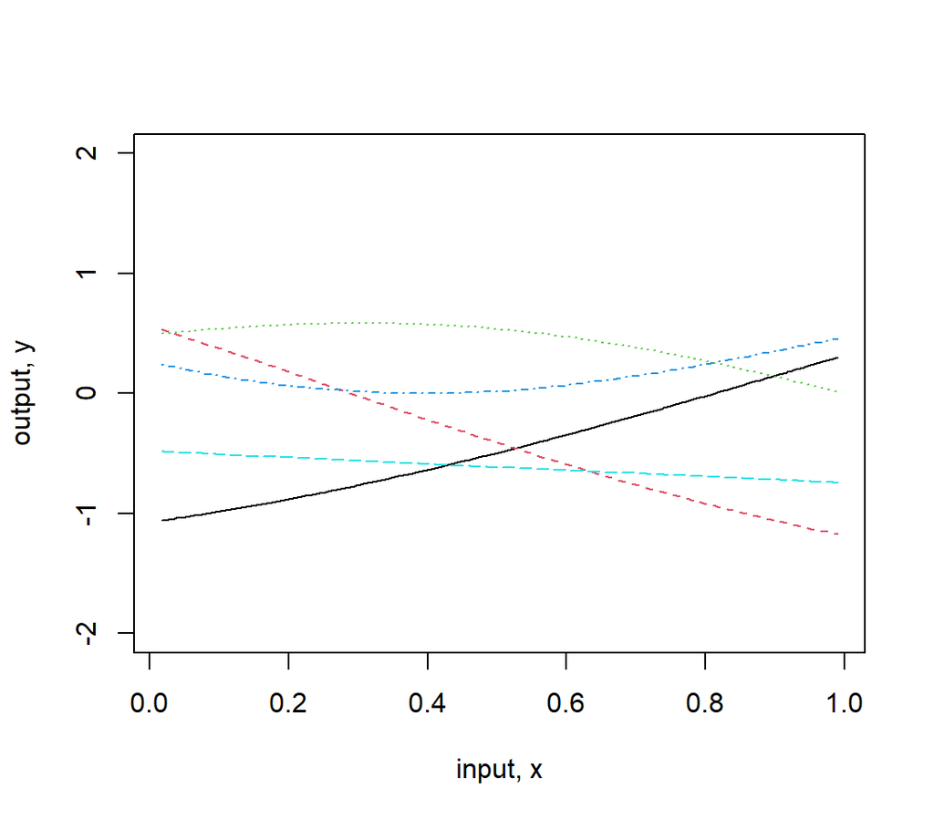

```r
set.seed(55)
## for one squared exponential kernel ---------------------------------------------
## simulate 100 points
x <- runif(100)
## compute distance matrix
d <- abs(outer(x, x, FUN = "-"))
## the characteristic length scale
l0 <- 1
# squared exponential kernel
kernel_se <- exp(-d^2 / (2 * l0^2))
sim <- mvtnorm::rmvnorm(5, sigma = kernel_se)
data <- cbind(x, t(sim)) %>%
    data.frame() %>%
    arrange(by = x)
matplot(data[, 1], data[, -1], "l",
        xlab = "input, x", ylab = "output, y",
        ylim = c(-2, 2))
```

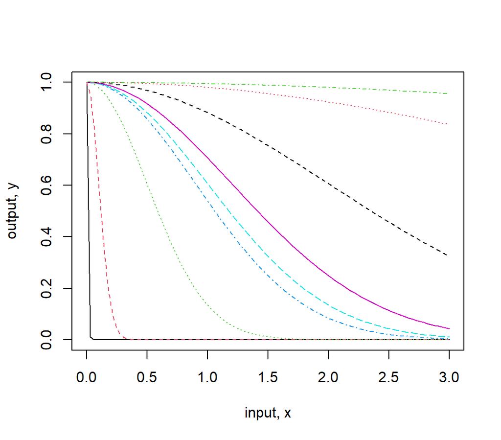

```r
r = seq(0, 3, len = 100)
l1 <- c(0.01, 0.1,  0.5,
         0.9,   1,  1.2,
           2,   5,  10)

kernel_se <- matrix(data = NA, nrow = length(l1), ncol = length(r))
for (i in 1:9) {
  for (j in 1:length(r)) {
    kernel_se[i, j] <- exp(-r[j]^2 / (2 * l1[i]^2))
  }
}
matplot(r, t(kernel_se),
        xlab = "input, x", ylab = "output, y",
        "l")
```

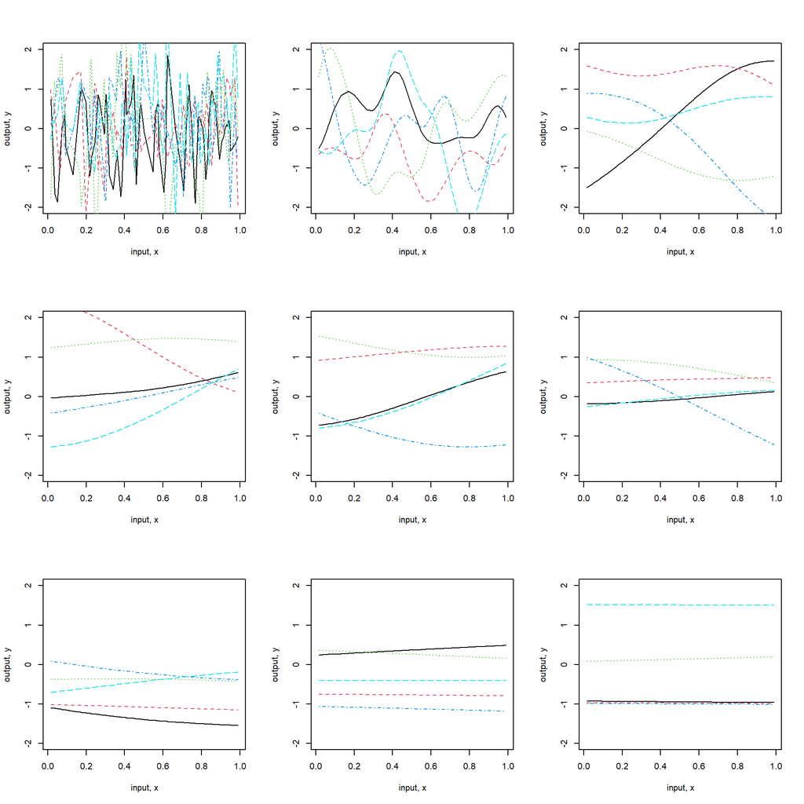

```r
## change the characteristic length ---------------------------------------------

l1 <- c(0.01, 0.1,  0.5,
         0.9,   1,  1.2,
           2,   5,  10)
op <- par(mfrow = c(3, 3))
for (i in 1:9) {
  kernel_se <- exp(-d^2 / (2 * l1[i]^2))
  sim <- mvtnorm::rmvnorm(5, sigma = kernel_se)
  data <- cbind(x, t(sim)) %>%
    data.frame() %>%
    arrange(by = x)
  matplot(data[, 1], data[, -1],
          xlab = "input, x", ylab = "output, y",
          "l", ylim = c(-2, 2))
}
```

```r
par(op)
```

```r
get_se_Sigma <- function(X1, X2, l = 1) {
  Sigma <- matrix(rep(0, length(X1) * length(X2)),
                  nrow = length(X1))

  for (i in 1:nrow(Sigma)) {
    for (j in 1:ncol(Sigma)) {
      Sigma[i, j] <- exp(-0.5 * (abs(X1[i] - X2[j]) / l)^2)
    }
  }
  return(Sigma)
}
```

#### The Matern Class of Covariance Functions

$$k_{Matern}(r) = \frac {2^{1-\nu}} {\Gamma(\nu)}
\Big( \frac {\sqrt{2\nu }r} l \Big)^ \nu
K_\nu \Big(\frac {\sqrt{2\nu }r} {l}\Big)
\ \ \ \ (4.14)$$

$K_{\nu}$ is a modified Bessel function!! Check what is a [Bessel function](https://mathworld.wolfram.com/BesselFunctionoftheFirstKind.html)

$$S(s) = \frac {2^D \pi^{D/2} \Gamma (\nu + D/2)(2\nu)^\nu}
{\Gamma(\nu)l^{2\nu}}
\Big(\frac {2\nu} {l^2} + 4\pi^2s^2\Big)^{-(\nu + D/2)}
\ \ \ \ (4.15)$$

$$k_{\nu=p+1/2}(r) =
exp \Big(- \frac {\sqrt{2\nu} r} l\Big)
\frac {\Gamma(p+1)} {\Gamma(2p+ 1)}
\sum^p_{i=0}
\frac {(p + i)!} {i!(p - i)!}
\Big(\frac {\sqrt {8\nu}r } l\Big) ^ {p-i}
\ \ \ \ (4.16)$$

$$k_{\nu=1/2}(r) = exp(-\frac r l) \ \ \ \ (4.17a)\\
k_{\nu=3/2}(r) = \Big(1 + \frac {\sqrt 3r} l \Big)
exp \Big(- \frac {\sqrt 3r} {l}\Big) \ \ \ \ (4.17b)\\
k_{\nu=5/2}(r) = \Big(1 + \frac {\sqrt 5r} l +
\frac {5r^2} {3l^2}\Big) exp \Big(- \frac {\sqrt 5r} l\Big)
\ \ \ \ (4.17c)$$

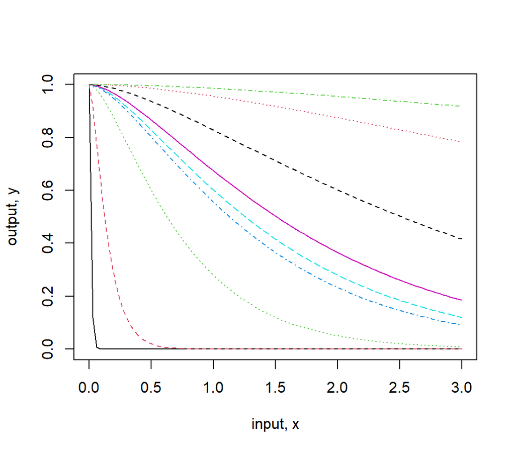

```r
## change the scale length ---------------------------------------------
r = seq(0, 3, len = 100)
l1 <- c(0.01, 0.1,  0.5,
         0.9,   1,  1.2,
           2,   5,  10)
kernel_mat <- matrix(data = NA, nrow = length(l1), ncol = length(r))
for (i in 1:9) {
  for (j in 1:length(r)) {
    kernel_mat[i, j] <- geoR::matern(r[j], phi = l1[i], kappa = 1)
  }
}
matplot(r, t(kernel_mat), "l",
        xlab = "input, x", ylab = "output, y")
```

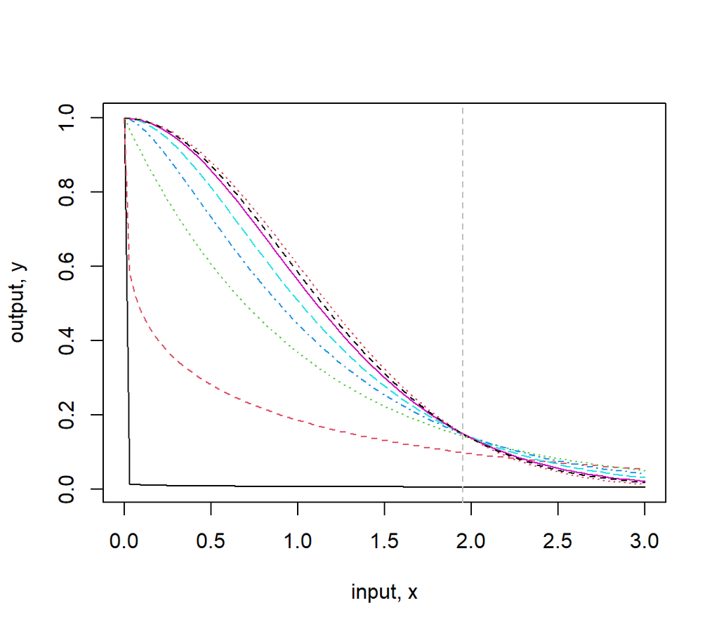

```r
## change the degree of freedom ---------------------------------------------

nu <- c(0.001, 0.1, 0.5,
        1, 2, 5,
        10, 100, 1000)
kernel_mat_df <- matrix(data = NA, nrow = length(l1), ncol = length(r))
for (i in 1:9) {
  for (j in 1:length(r)) {
    kernel_mat_df[i, j] <- geoR::matern(r[j],
                                        phi = 1/(sqrt(2 * nu[i])),
                                        kappa = nu[i])
  }
}
matplot(r, t(kernel_mat_df),
        xlab = "input, x", ylab = "output, y",
        "l")
abline(v = 1.95, lty = "dashed", col = "grey")
```

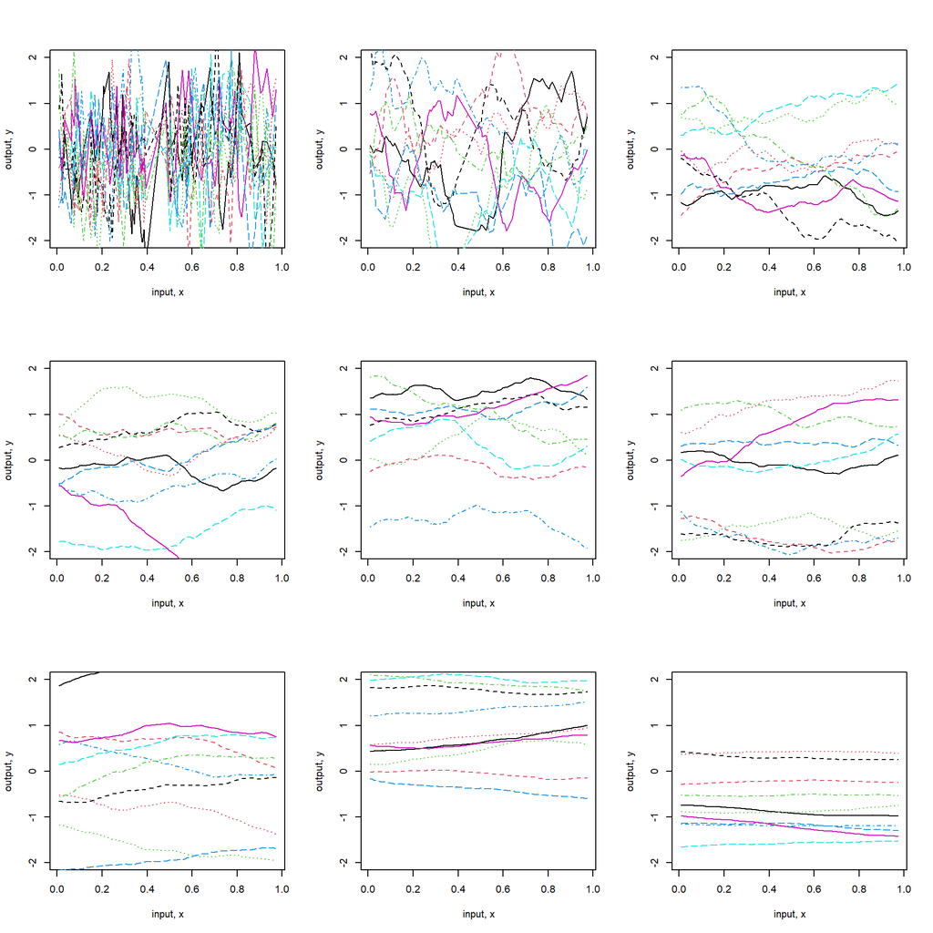

```r
l1 <- c(0.01, 0.1,  0.5,
         0.9,   1,  1.2,
           2,   5,  10)
op <- par(mfrow = c(3, 3))
x <- runif(100)
d <- abs(outer(x, x, FUN = "-"))
for (i in 1:9) {
  ## \phi is the l scale in GP book
  ## \kappa is the \mu in GP book
  kernel_mat <- geoR::matern(d, phi = l1[i], kappa = 1)
  sim <- mvtnorm::rmvnorm(10, sigma = kernel_mat)
  data <- cbind(x, t(sim)) %>%
    data.frame() %>%
    arrange(by = x)
  matplot(data[, 1], data[, -1],
          xlab = "input, x", ylab = "output, y",
          "l", ylim = c(-2, 2))
}
```

```r
par(op)
```

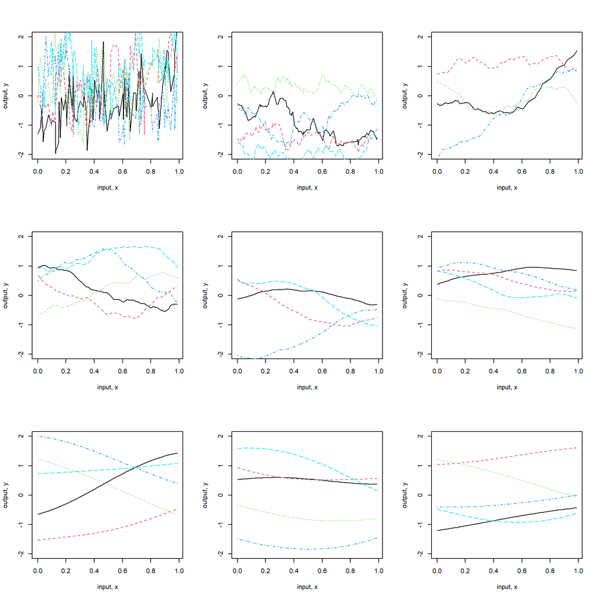

```r
set.seed(555)
nu <- c(0.1, 0.5, 0.9, 1,
        1.5, 2, 5, 10, 20)
op <- par(mfrow = c(3, 3))
x <- runif(100)
d <- abs(outer(x, x, FUN = "-"))
for (i in 1:9) {
  ## \phi is the l / (sqrt(2*\kappa))  scale in GP book
  ## \kappa is the \nu in GP book
  kernel_mat <- geoR::matern(d, phi = 1/(sqrt(2 * nu[i])), kappa = nu[i])
  kernel_mat <- get_symm(t(kernel_mat))
  kernel_mat[is.na(kernel_mat)] <- 0

  sim <- mvtnorm::rmvnorm(5, sigma = kernel_mat)
  data <- cbind(x, t(sim)) %>%
    data.frame() %>%
    arrange(by = x)
  matplot(data[, 1], data[, -1],
          xlab = "input, x", ylab = "output, y",
          "l", ylim = c(-2, 2))
}
```

```r
par(op)

## use besselK() for the Bessel functions
```

Ornstein-Uhlenbeck Process and Exponential Covariance Function

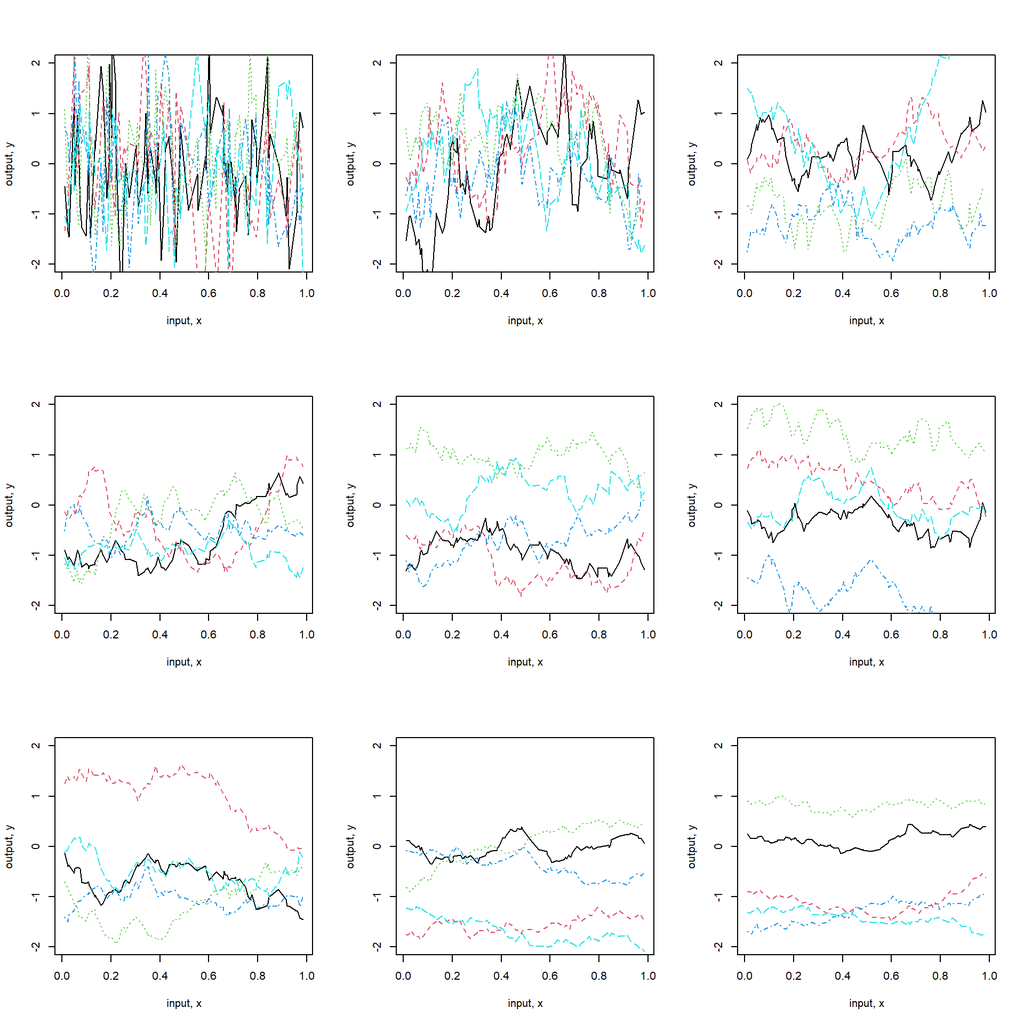

```r
l1 <- c(0.01, 0.1,  0.5,
         0.9,   1,  1.2,
           2,   5,  10)

op <- par(mfrow = c(3, 3))
x <- runif(100)
d <- abs(outer(x, x, FUN = "-"))

for (i in 1:9) {
  kernel_ou <- exp(-d / l1[i])
  sim <- mvtnorm::rmvnorm(5, sigma = kernel_ou)
  data <- cbind(x, t(sim)) %>%
    data.frame() %>%
    arrange(by = x)
  matplot(data[, 1], data[, -1],
          xlab = "input, x", ylab = "output, y",
          "l", ylim = c(-2, 2))
}
```

```r
par(op)
```

#### The $\gamma$-exponential Covariance Function

$$k(r) = exp\Big( - \big(\frac r l\big) \Big)^\gamma,\ for\ 0 < \gamma \neq 2
\ \ \ \ (4.18)$$

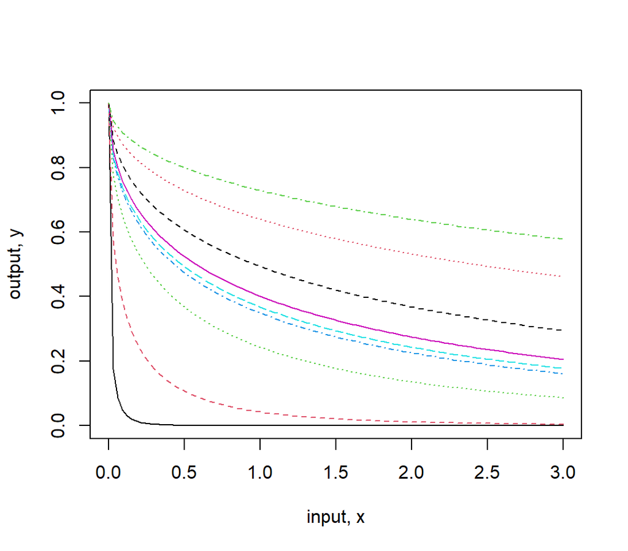

```r
## change the scale length ---------------------------------------------
l1 <- c(0.01, 0.1,  0.5,
         0.9,   1,  1.2,
           2,   5,  10)
kernel_gamma <- matrix(data = NA, nrow = length(l1), ncol = length(r))
for (i in 1:9) {
  for (j in 1:length(r)) {
    kernel_gamma[i, j] <- exp(- (r[j] / l1[i])^0.5)
  }
}
matplot(r, t(kernel_gamma),
        xlab = "input, x", ylab = "output, y", "l")
```

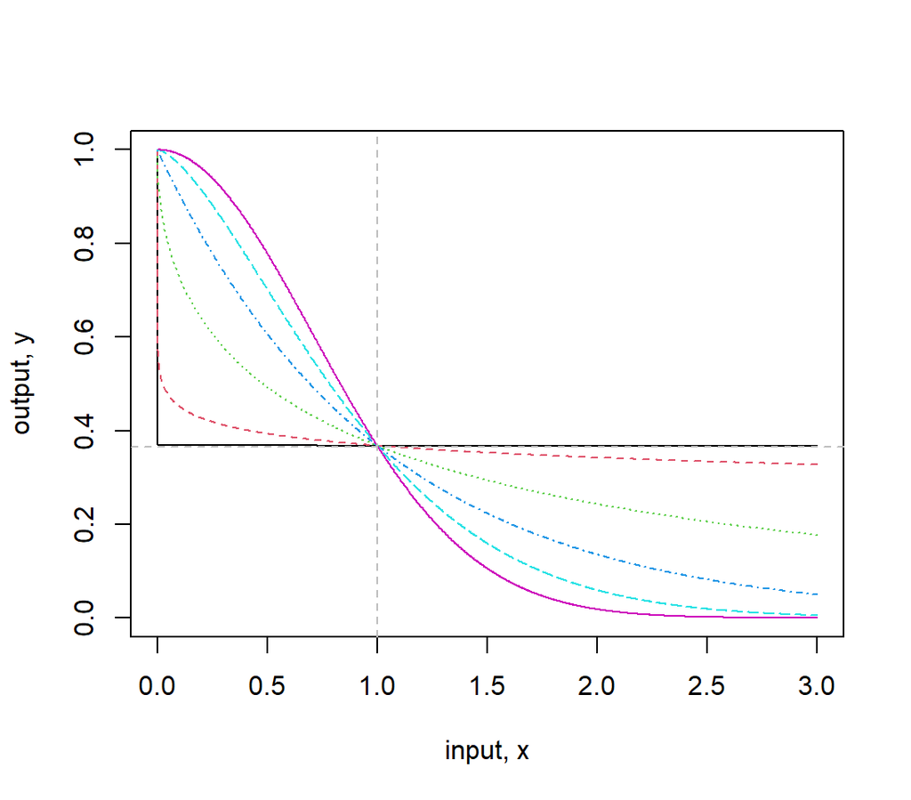

```r
## change the degree of freedom ---------------------------------------------
r = seq(0, 3, len = 1000)
gamma <- c(0.001, 0.1, 0.5,
          1, 1.5, 2)
kernel_gammaex <- matrix(data = NA, nrow = 6, ncol = length(r))
for (i in 1:6) {
  for (j in 1:length(r)) {
    kernel_gammaex[i, j] <- exp(-(r[j])^gamma[i])
  }
}
matplot(r, t(kernel_gammaex),
        xlab = "input, x", ylab = "output, y",
        "l")
abline(v = 1, h = 0.365, lty = "dashed", col = "grey")
```

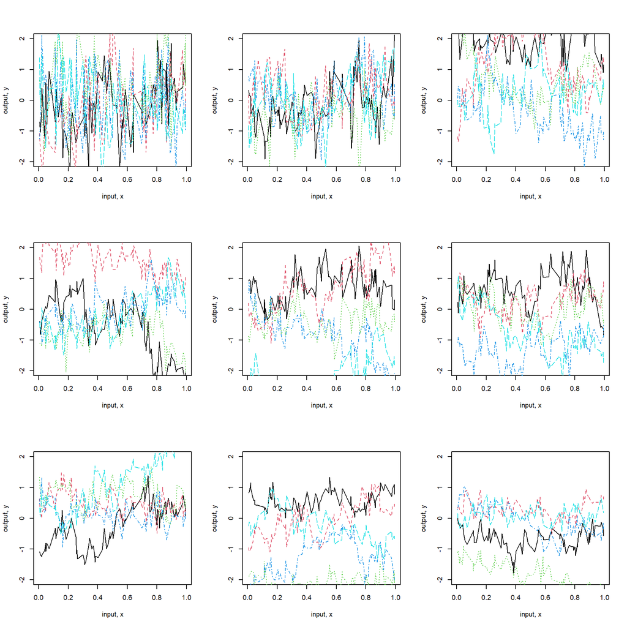

```r
l1 <- c(0.01, 0.1,  0.5,
         0.9,   1,  1.2,
           2,   5,  10)

op <- par(mfrow = c(3, 3))
x <- runif(100)
d <- abs(outer(x, x, FUN = "-"))

for (i in 1:9) {
  kernel_gammaex <- exp(- (d / l1[i])^0.5)
  sim <- mvtnorm::rmvnorm(5, sigma = kernel_gammaex)
  data <- cbind(x, t(sim)) %>%
    data.frame() %>%
    arrange(by = x)
  matplot(data[, 1], data[, -1],
          xlab = "input, x", ylab = "output, y",
          "l", ylim = c(-2, 2))
}
```

```r
par(op)
```

#### Rational Quadratic Covariance Function

$$k_{RQ}(r) = \Big(1 + \frac {r^2} {2\alpha l^2} \Big)^{-\alpha}
\ \ \ \ (4.19)$$

$$k_{RQ}(r) = \int p(\tau|\alpha,\ \beta)k_{SE}(r|\tau) d\tau\\
\propto \int \tau^{\alpha -1}
exp \Big(- \frac {\alpha \tau} \beta \Big)
exp \Big(- \frac {\tau r^2} 2\Big) d\tau\\
\propto \Big(1 + \frac {r^2} {2\alpha l^2}\Big)^{-\alpha}
\ \ \ \ (4.20)$$

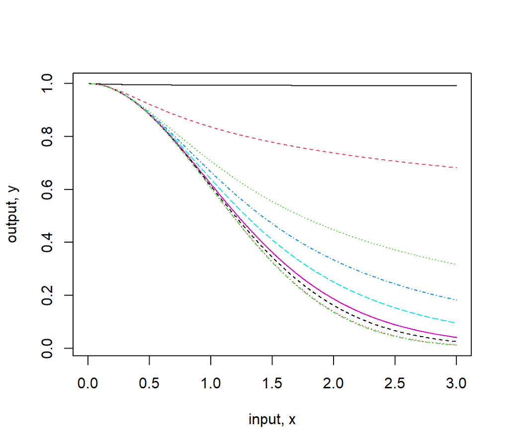

```r
## change the alpha ---------------------------------------------
alpha <- c(0.001, 0.1, 0.5,
          1, 2, 5,
          10, 100, 1000)
kernel_rq <- matrix(data = NA, nrow = length(alpha), ncol = length(r))
for (i in 1:9) {
  for (j in 1:length(r)) {
    kernel_rq[i, j] <- (1 + r[j]^2 / (2 * alpha[i]))^(-alpha[i])
  }
}
matplot(r, t(kernel_rq),
        xlab = "input, x", ylab = "output, y",
        "l")
```

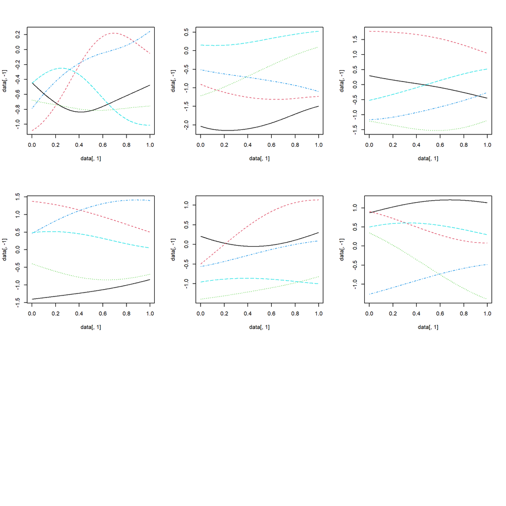

```r
alpha <- c(0.5, 1, 2,
          10, 100, 1000)
op <- par(mfrow = c(3, 3))
x <- runif(1000)
d <- abs(outer(x, x, FUN = "-"))

for (i in 1:6) {
  kernel_rq_alpha <- (1 + d^2 / (2 * alpha[i]))^(-alpha[i])
  sim <- mvtnorm::rmvnorm(5, sigma = kernel_rq_alpha)
  data <- cbind(x, t(sim)) %>%
    data.frame() %>%
    arrange(by = x)
  matplot(data[, 1], data[, -1], "l")
}

par(op)
```

Piecewise Polynomial Covariance Functions with Compact Support

$$k_{ppD,0}(r) = (1 - r)^j_+,\ \
where\ j = \lfloor \frac D 2 \rfloor
+ q + 1 \ \ \ \ (4.21a)\\
k_{ppD,1}(r) = (1 - r)^{j+1}_{+}
\big((j + 1)r + 1\big)
\ \ \ \ (4.21b)\\
k_{ppD,2}(r) = (1 - r)^{j+2}_{+}
\big((j^2 + 4j + 3)r^2 + (3j + 6)r + 3\big)/3 \ \ \ \ (4.21c)\\
k_{ppD,3}(r) = (1 - r)^{j+3}_{+}
\big((j^3 + 9j^2 + 23j + 15)r^3+
(6j^2 + 36j + 45)r^2 + (15j + 45)r + 15\big)/15
\ \ \ \ (4.21d)$$

Further Properties of Stationary Covariance Functions

$$r^2(x,\ x') = (x - x')^{\top}M(x - x')\\
M = \Lambda\Lambda^{\top} + \Psi
\ \ \ \ (4.22)$$

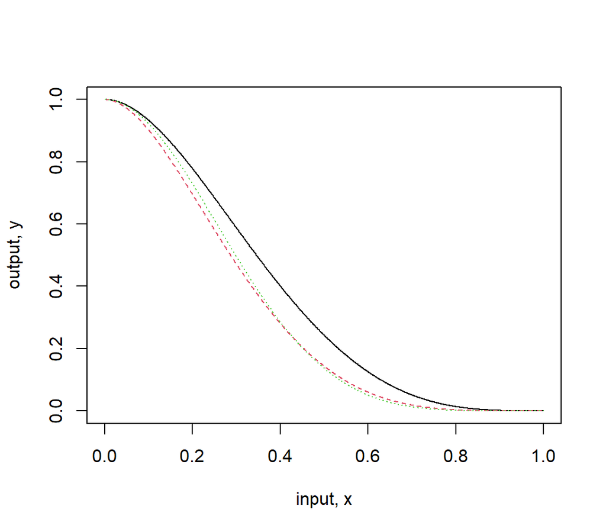

```r
r = seq(0, 1, len = 1000)
kernel_pp <- matrix(data = NA, nrow = 3, ncol = length(r))
D = c(1, 3, 1)
q = c(1, 1, 2)
j <- D/2 + q + 1

for (n in 1:length(r)) {
  ## D =1 q =1
  kernel_pp[1, n] <- max(c((1 - r[n])^(j[1] + 1), 0)) * ((j[1] + 1) * r[n] + 1)
  kernel_pp[2, n] <- max(c((1 - r[n])^(j[2] + 1), 0)) * ((j[2] + 1) * r[n] + 1)
  kernel_pp[3, n] <- max(c((1 - r[n])^(j[3] + 2), 0)) * ((j[3]^2 + 4 * j[3] + 3) * r[n]^2 +(3 * j[3] + 6) * r[n] + 3) / 3
}
# View(kernel_pp)
matplot(r, t(kernel_pp),
        xlab = "input, x", ylab = "output, y", "l")
```

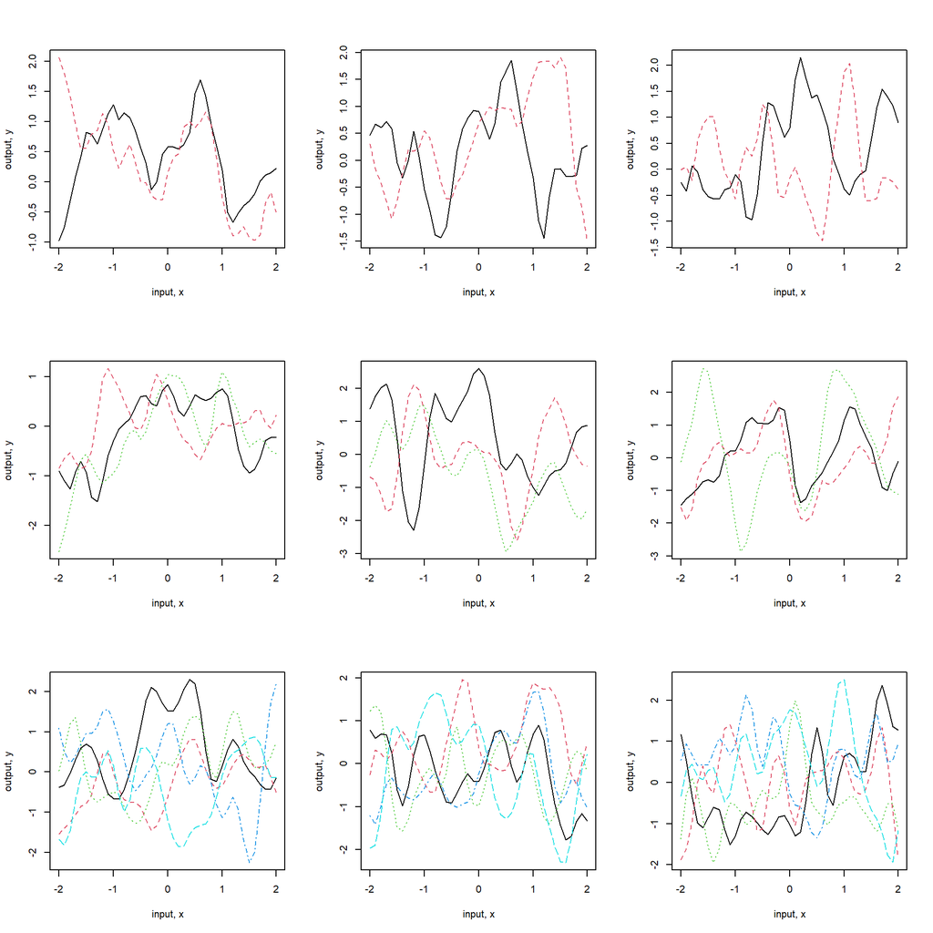

```r
x <- seq(-2, 2, by = 0.1)
r <- abs(outer(x, x, FUN = "-"))
r[r > 1] = 1

op <- par(mfrow = c(3, 3))
## q=1 ---------------------------------------------
D <- c(1, 2, 3)
q <- 1
j <- D/2 + q + 1
for (i in 1:3) {
  kernel_pp_q1 <- (1 - r)^{j[i] + 1} *
    ((j[i] + 1) * r + 1) %>% get_symm()
  # fields::image.plot(x, x, kernel_pp_q1)
  # chol(kernel_pp_q1)
  # View(kernel_pp_q1)
  # solve(kernel_pp_q1) %>% View()
  sim <- mvtnorm::rmvnorm(2, sigma = kernel_pp_q1)
  data <- cbind(x, t(sim)) %>%
    data.frame() %>%
    arrange(by = x)
  matplot(data[, 1], data[, -1], xlab = "input, x", ylab = "output, y", "l")
}


## q=2 ---------------------------------------------
D <- c(1, 2, 3)
q <- 2
j <- D/2 + q + 1
for (i in 1:3) {
  kernel_pp_q2 <- (1 - r)^(j[i] + 2) *
    ((j[i]^2 + 4 * j[i] + 3) * r^2 +
       (3 * j[i] + 6) * r + 3) / 3 %>% get_symm()
  sim <- mvtnorm::rmvnorm(3, sigma = kernel_pp_q2)
  data <- cbind(x, t(sim)) %>%
    data.frame() %>%
    arrange(by = x)
  matplot(data[, 1], data[, -1], xlab = "input, x", ylab = "output, y", "l")
}

## q=3 ---------------------------------------------
D <- c(1, 2, 3)
q <- 3
j <- D/2 + q + 1

for (i in 1:3) {
  kernel_pp_q3 <- ((1 - r)^(j[i] + 3) *
    ((j[i]^3 + 9 * j[i]^2 + 23 * j[i] + 15) * r^3 +
       (6 * j[i]^2 + 36 * j[i] + 45) * r^2 +
       (15 * j[i] + 45) * r +
       15) / 15 ) %>% get_symm()
  # View(kernel_pp_q3)
  # fields::image.plot(kernel_pp_q3)
  # isSymmetric.matrix(kernel_pp_q3)
  sim <- mvtnorm::rmvnorm(5, sigma = kernel_pp_q3)
  data <- cbind(x, t(sim)) %>%
    data.frame() %>%
    arrange(by = x)
  matplot(data[, 1], data[, -1], xlab = "input, x", ylab = "output, y", "l")
}
```

```r
par(op)
```

Stationary kernels can also be defined on a periodic domain, and can be readily constructed from stationary kernels on $\mathbb R$. Given a stationary kernel $k(x)$, the kernel $k_{\mathbb T}(x) = \sum_{m\in Z} k(x + ml)$ is periodic with period $l$.

### 4.2.2 Dot Product Covariance Functions

```r
x <- seq(0, 1, length = 100)
input <- cbind(x, x^2) %>%
  data.frame() %>%
  select(x = 1, xseq = 2)
sigma <- 0.1
kernel_dot <- geometry::dot(input, input, d = T)
kernel_dot
```

```
       x     xseq
33.50168 20.30337
```

$$k(x,\ x') = \sigma_0^2 + x \cdot x'\\
k(x,\ x') = \sigma_0^2 + x^{\top}\Sigma_px' \\
k(x,\ x') = (\sigma_0^2 + x^{\top}\Sigma_px')^p$$

$$k(x,\ x') = (x \cdot x')^p =
\Big(\sum^D_{d=1}x_dx_d')^p \\
= \Big(\sum^D_{d_1=1}x_{d1}x_{d1}'\Big)...
\Big(\sum^D_{d_p=1}x_{dp}x_{dp}'\Big)\\
= \sum_{d_1 = 1}^D ... \sum_{d_p = 1}^D
(x_{d_1}...x_{d_p})(x_{d_1}'...x_{d_p}') \\
\stackrel {\Delta}{=} \phi (x) \cdot \phi(x')
\ \ \ \ (4.23)$$

$$\phi_m(x) = \sqrt {\frac {p!} {m_1!\ ... !\ m_D!}} x_1^{m1}\ ...\ x_D^{m_D}
\ \ \ \ (4.24)\\
for\ p = 2\ in\ D = 2,\ \phi(x) = (x^2_1,\ x^2_2,\ \sqrt 2x_1x_2)^{\top}$$

### 4.2.3 Other Non-stationary Covariance Functions

#### Neural network kernel by *Neal (1996)*

$$f(x) = b + \sum^{N_H}_{j=1}
\nu_j h(x;\ u_j)
\ \ \ \ (4.25)$$

$$\mathbb E_w[f(x)] = 0 \ \ \ \ (4.26)\\
\mathbb E_w[f(x)f(x')] = \sigma_b^2 +
\sum_j \sigma^2_\nu \mathbb E_u[h(x;\ u_j)h(x';\ u_j)]
\ \ \ \ (4.27)\\
= \sigma_b^2 + N_H \sigma_\nu^2 \mathbb E_u[h(x;\ u)h(x';\ u)] \ \ \ \ (4.28)$$

$$h(z) = erf(z) = \frac 2 {\sqrt \pi} \int_0^z e^{-t^2} dt\\
h(x;\ u) = erf(u_0 + \sum^D_{j=1} u_jx_j) ,\ \ \
u \sim \mathcal N(0,\ \Sigma)\\
k_{NN}(x,\ x') = \frac 2 \pi \sin^{-1}
\Bigg(\frac {2 \bar x^{\top}\Sigma \bar x'}
{\sqrt{(1 + 2\bar x^{\top}\Sigma \bar x) (1 + 2\bar x'^{\top}\Sigma \bar x')}}\Bigg)
\ \ \ \ (4.29)$$

```r
## X as \tilde x two dimensional vector augmented with 1s
x0 <- 1
x1 <- seq(-4, 4, length = 100)

## check the X is a column vector
## each value in X is a two dimension vector
X <- cbind(x0, x1)
# View(X %*% Sigma %*% t(X))

Sigma <- matrix(c(100, 0, 0, 100), nrow = 2)
insin <- matrix(NA, nrow = nrow(X), ncol = nrow(X))
for (i in seq_along(1:nrow(X))) {
  for (j in seq_along(1:nrow(X))) {
    insin[i, j] <- 2 * X[i, ] %*% Sigma %*% X[j, ] /
      sqrt((1 + 2 * X[i, ] %*% Sigma %*% X[i, ]) * (1 + 2 * X[j, ] %*% Sigma %*% X[j, ]))
  }
}

knn <- 2 / pi * asin(insin)
```

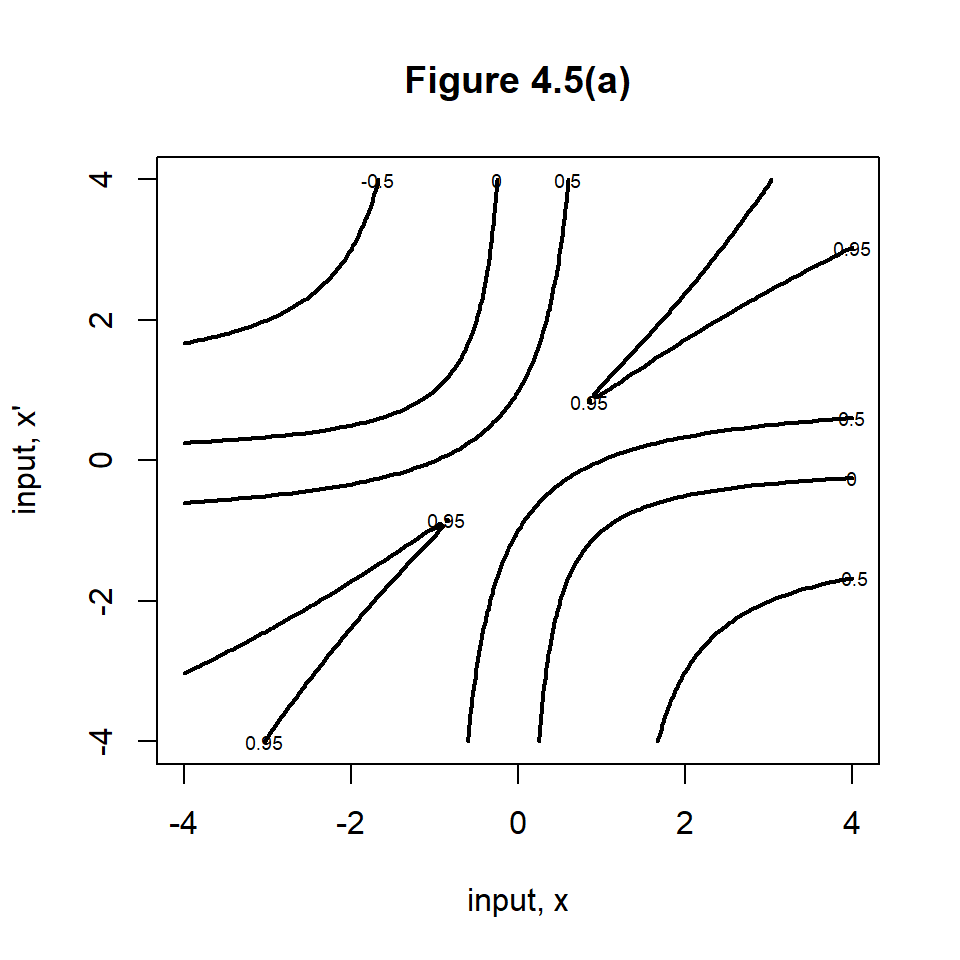

```r
contour(x1, x1, knn,
        ylim = c(-4, 4),
        levels = c(-0.5, 0, 0.5, 0.95),
        lwd = 2,
        method = "simple",
        xlab = "input, x",
        ylab = "input, x'",
        main = "Figure 4.5(a)")
```

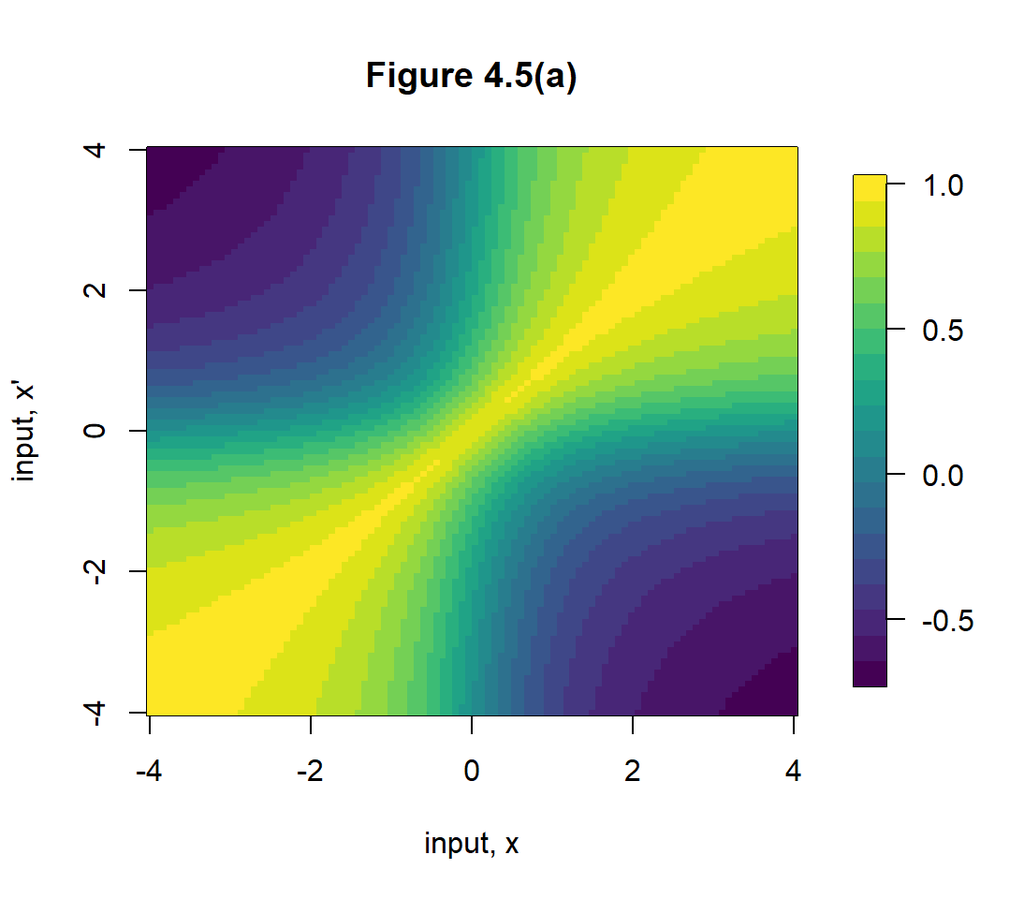

```r
fields::image.plot(x1, x1, knn,
                   xlab = "input, x",
                   ylab = "input, x'",
                   main = "Figure 4.5(a)",
                   nlevel = 20,
                   col = viridis::viridis(20))
```

```r
kernel_nn <- function(sigma_e = 10,
                      sigma_f = 10,
                      xmin = -4,
                      xmax = 4,
                      length = 100) {
  x0 <- 1
  x1 <- seq(xmin, xmax, length = length)
  X <- cbind(x0, x1)
  Sigma <- matrix(c(sigma_e^2, 0, 0, sigma_f^2), nrow = 2)
  insin <- matrix(NA, nrow = nrow(X), ncol = nrow(X))
  for (i in seq_along(1:nrow(X))) {
    for (j in seq_along(1:nrow(X))) {
      insin[i, j] <- 2 * X[i, ] %*% Sigma %*% X[j, ] /
        sqrt((1 + 2 * X[i, ] %*% Sigma %*% X[i, ]) * (1 + 2 * X[j, ] %*% Sigma %*% X[j, ]))
    }
  }
  knn <- 2 / pi * asin(insin)
}
```

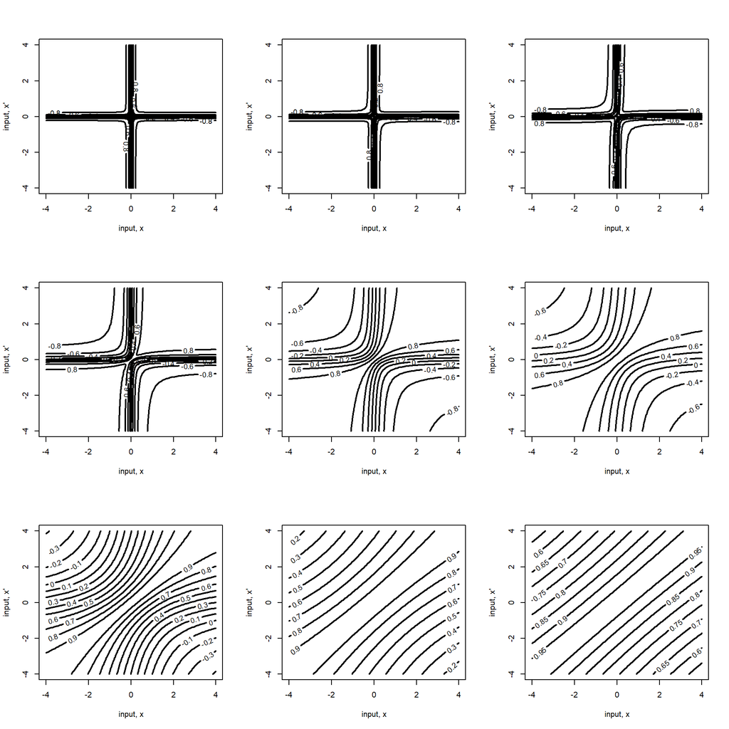

```r
op <- par(mfrow = c(3, 3))
## changing the sigma_e
walk(c(0.1, 0.5, 1,
      2, 5, 10,
      20, 50, 100),
    ~ kernel_nn(sigma_e = .x,
                sigma_f = 10,
                xmin = -4,
                xmax = 4,
                length = 100) %>%
      contour(x1, x1, .,
              lwd = 2,
              xlab = "input, x",
              ylab = "input, x'"))
```

```r
par(op)
```

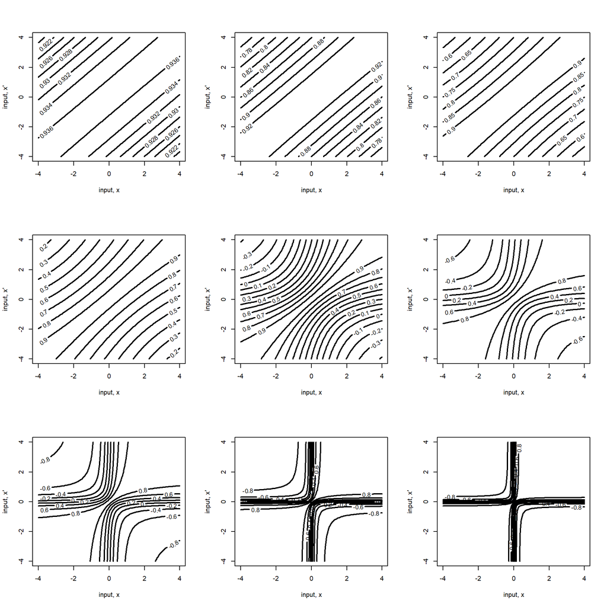

```r
op <- par(mfrow = c(3, 3))
## changing the sigma_e
walk(c(0.1, 0.5, 1,
      2, 5, 10,
      20, 50, 100),
    ~ kernel_nn(sigma_e = 10,
                sigma_f = .x,
                xmin = -4,
                xmax = 4,
                length = 100) %>%
      contour(x1, x1, .,
              lwd = 2,
              xlab = "input, x",
              ylab = "input, x'"))
```

```r
par(op)
```

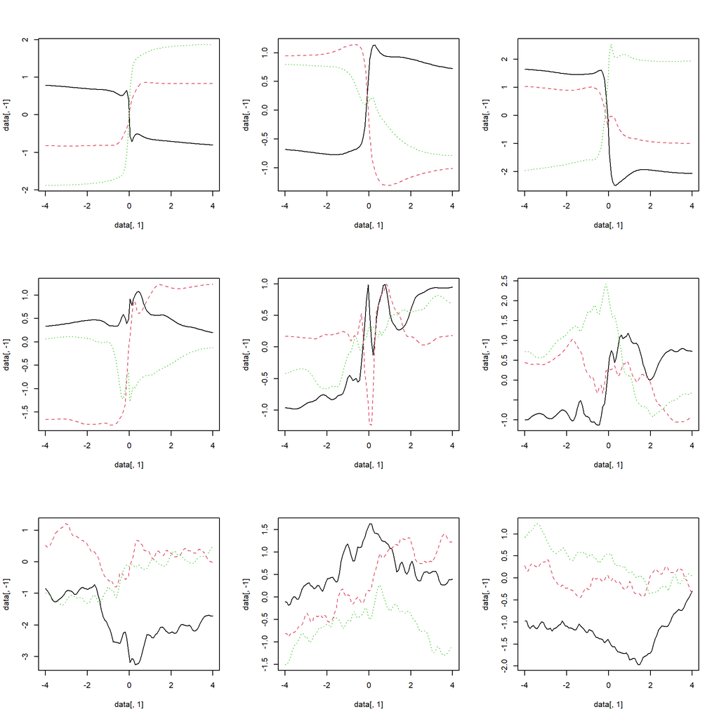

```r
op <- par(mfrow = c(3, 3))
x <- seq(-4, 4, length = 100)
sigma <- c(0.1, 0.5, 1,
           2, 5, 10,
           20, 50, 100)

for (i in 1:9) {
  sim <- mvtnorm::rmvnorm(3, sigma = kernel_nn(sigma_e = sigma[i]))
  data <- cbind(x, t(sim)) %>%
    data.frame() %>%
    arrange(by = x)
  matplot(data[, 1], data[, -1], "l")
}
```

```r
par(op)
```

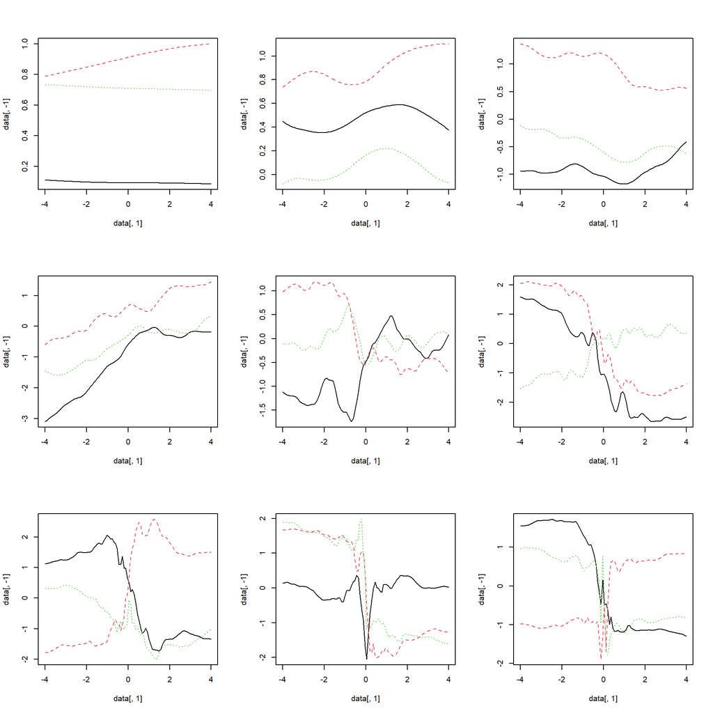

```r
op <- par(mfrow = c(3, 3))
x <- seq(-4, 4, length = 100)
sigma <- c(0.1, 0.5, 1,
           2, 5, 10,
           20, 50, 100)

for (i in 1:9) {
  sim <- mvtnorm::rmvnorm(3, sigma = kernel_nn(sigma_f = sigma[i]))
  data <- cbind(x, t(sim)) %>%
    data.frame() %>%
    arrange(by = x)
  matplot(data[, 1], data[, -1], "l")
}
```

```r
par(op)
```

#### Generalizednon stationary covariance function

the squared exponential $k_G(\pmb x, \pmb x') \propto \exp(-|x - x'|^2/4\sigma_g^2)$.

For a finite value of $\sigma_u^2$, $k_G(\pmb x, \pmb x')$ comprises a squared exponential covariance function modulated by the Gaussian decay envelope function $\exp \bigg(- \frac {\pmb x^{\top} \pmb x} {2\sigma_m^2}\bigg) \exp\bigg(- \frac {\pmb x' ^{\top} \pmb x'} {2 \sigma_m^2}\bigg)$, cf. the vertical rescaling construction in **section 4.2.4**

$$h(x;\ u) = exp\Big(-\frac {|x - u|^2} {2\sigma^2_g}\Big),\ \
u \sim \mathcal N(\pmb0,\ \sigma_u^2I)\\
k_G(x,\ x') = \frac 1 {(2\pi \sigma^2_u)^ {d/2}}
\int exp \Big(- \frac {|x-u|^2} {2\sigma_g^2} -
\frac {|x'-u|^2} {2\sigma_g^2} -
\frac {u^{\top}u} {2\sigma_u^2} \Big)du\\
= \Big(\frac {\sigma_{\epsilon}} {\sigma_u}\Big)^d
exp \Big(- \frac {x^{\top}x} {2\sigma ^2_m}\Big)
exp \Big(- \frac {|x - x'|^2} {2\sigma_s^2}\Big)
exp \Big(- \frac {x'^{\top}x'} {2\sigma_m^2}\Big)
\ \ \ \ (4.30)\\
\frac 1 {\sigma_\epsilon^2} = \frac 2 {\sigma_g^2} + \frac 1 {\sigma_u^2}\\
\sigma_s^2 = 2\sigma_g^2 + \frac {\sigma_g^4} {\sigma_u^2}\\
\sigma_m^2 = 2\sigma_u^2 + \sigma_g^2.$$

#### MacKay’s sin(x) cos(x) kernel

$$(\cos(x) - \cos(x'))^2 + (\sin(x) - \sin(x'))^2 = 4 \sin^2(\frac {x-x'} 2)\\
k(x,\ x') = exp \Big( - \frac {2 \sin^2(\frac {x-x'} 2)} {l^2}\Big)
\ \ \ \ (4.31)$$

```r
kernel_mackay <- function(xmin = -4,
                          xmax = 4,
                          length = 100,
                          scale = 1) {
  x <- seq(xmin, xmax, length = length)
  d <- abs(outer(x, x, FUN = "-"))
  kernel <- exp(- 2 * (sin(d / 2))^2 / scale^2)
  kernel <- get_symm(kernel)

  ## not suppose to do this,
  ## but working for current coding
  ## the first value is always NA?
  kernel[is.na(kernel)] <- 0
  return(kernel)
}
```

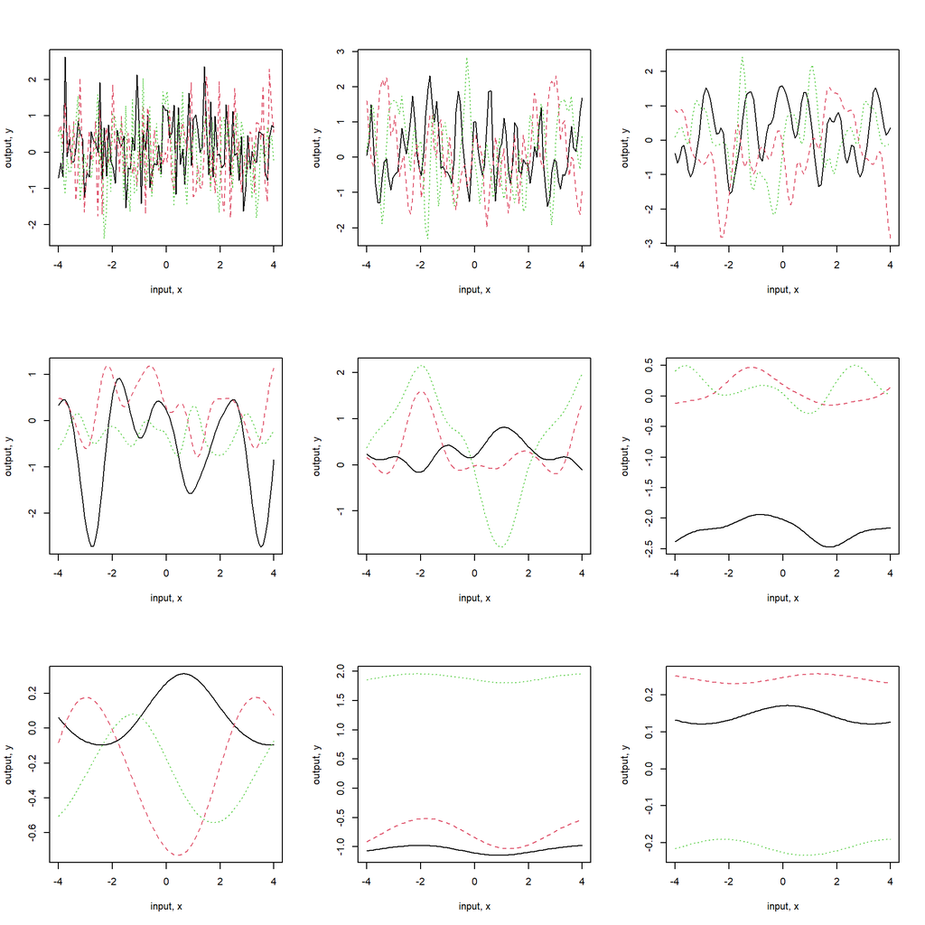

```r
op <- par(mfrow = c(3, 3))
x <- seq(-4, 4, length = 100)
l <- c(0.01, 0.1, 0.2,
       0.5, 1, 2,
       5, 10, 50)
for (i in 1:9) {
  sim <- mvtnorm::rmvnorm(3, sigma = kernel_mackay(scale = l[i]))
  data <- cbind(x, t(sim)) %>%
    data.frame() %>%
    arrange(by = x)
  matplot(data[, 1], data[, -1],
          xlab = "input, x", ylab = "output, y",
          "l")
}
```

```r
par(op)
```

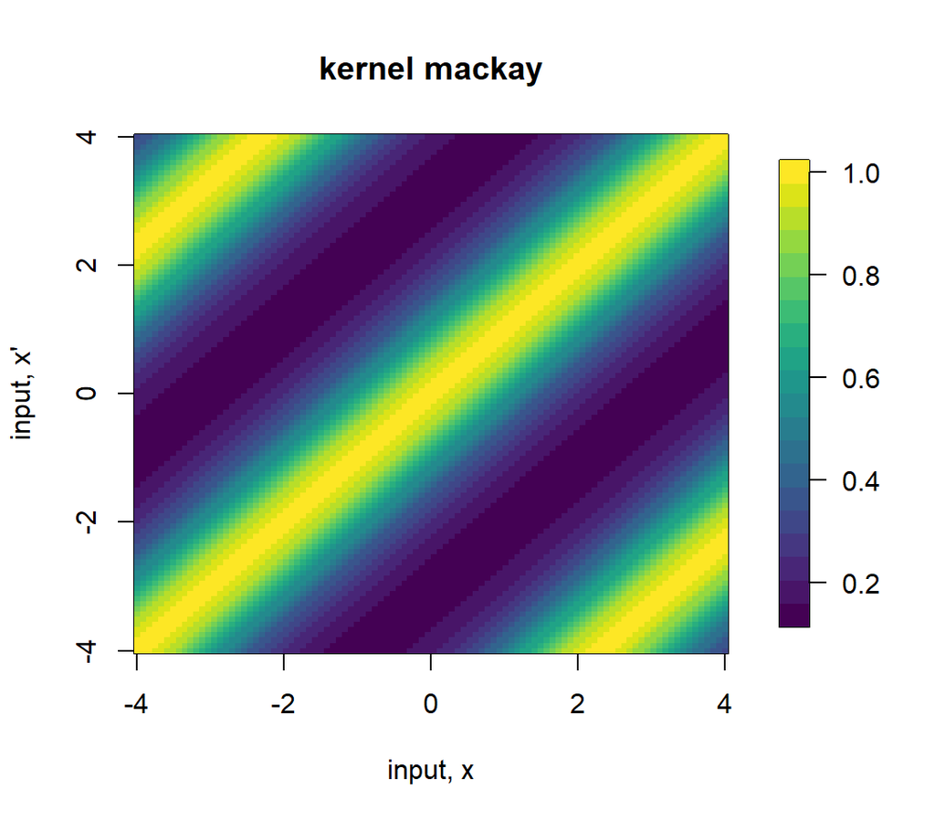

```r
x1 <- seq(-4, 4, length = 100)
kmack <- kernel_mackay()
fields::image.plot(x1, x1, kmack,
xlab = "input, x",
ylab = "input, x'",
main = "kernel mackay",
nlevel = 20,
col = viridis::viridis(20))
```

#### Gibbs Kernel

$$k(x,\ x') = \prod ^D_{d=1}\Big(\frac {2l_d(x)l_d(x')}
{l_d^2(x) + l_d^2(x')}\Big)^ {1/2}
exp \Big(- \sum_{d=1}^D \frac {(x_d - x'_d)^2} {l_d^2(x) + l_d^2(x')}\Big)\ \ \ \ (4.32)$$

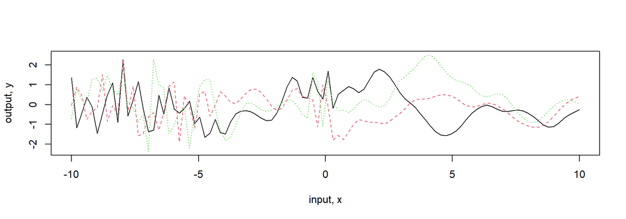

```r
## Gibbs kernel for d = 1
x <- seq(-10, 10, length = 100)
# lfunction <- function(x) abs(sin(x))^2
lfunction <- function(x) x^2 * exp(x)
# lfunction <- function(x) x^2
# lfunction <- function(x) exp(x)
# lfunction <- function(x) abs(x)

kernel_gibbs <- matrix(NA, nrow = length(x), ncol = length(x))
for (i in seq_along(1:length(x))){
  for (j in seq_along(1:length(x))){
    kernel_gibbs[i, j] <- sqrt(2 * lfunction(x[i]) * lfunction(x[j]) /
                                 (lfunction(x[i])^2 + lfunction(x[j])^2)) *
      exp(-(x[i] - x[j])^2 / (lfunction(x[i])^2 + lfunction(x[j])^2))
  }
}

kernel_gibbs <- get_symm(kernel_gibbs)
kernel_gibbs[is.na(kernel_gibbs)] <- 0
sim <- mvtnorm::rmvnorm(3, sigma = kernel_gibbs)
data <- cbind(x, t(sim)) %>%
    data.frame() %>%
    arrange(by = x)
matplot(data[, 1], data[, -1],
        xlab = "input, x", ylab = "output, y",
        "l")
```

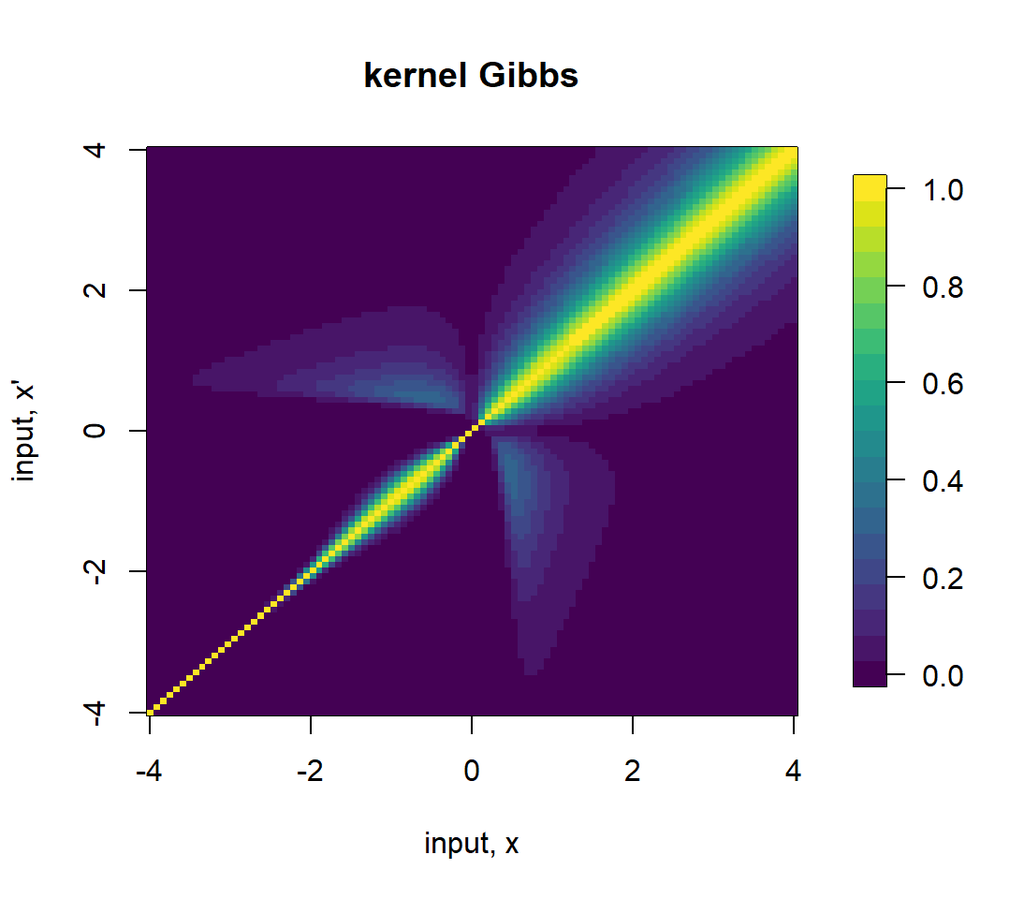

```r
x1 <- seq(-4, 4, length = 100)
fields::image.plot(x1, x1, kernel_gibbs,
xlab = "input, x",
ylab = "input, x'",
main = "kernel Gibbs",
nlevel = 20,
col = viridis::viridis(20))
```

$$Q_{ij} = (x_i - x_j)^{\top}((\Sigma_i + \Sigma_j)/2)^{-1}(x_i - x_j)
\ \ \ \ (4.33)$$

$$k_{NS}(x_i,\ x_j) = 2^{D/2}|\Sigma_i|^{1/4}
|\Sigma_j|^{1/4}|\Sigma_i + \Sigma_j|^{-1/2}k_S(Q_{ij})
\ \ \ \ (4.34)$$
#### Periodic (not in the book)

$$k_{PD}(x_i,\ x_j) = \sigma^2\cos\big(\omega(x - x')\big) \exp\Big(-\frac 1 {2l^2}(x - x')^2\Big)$$

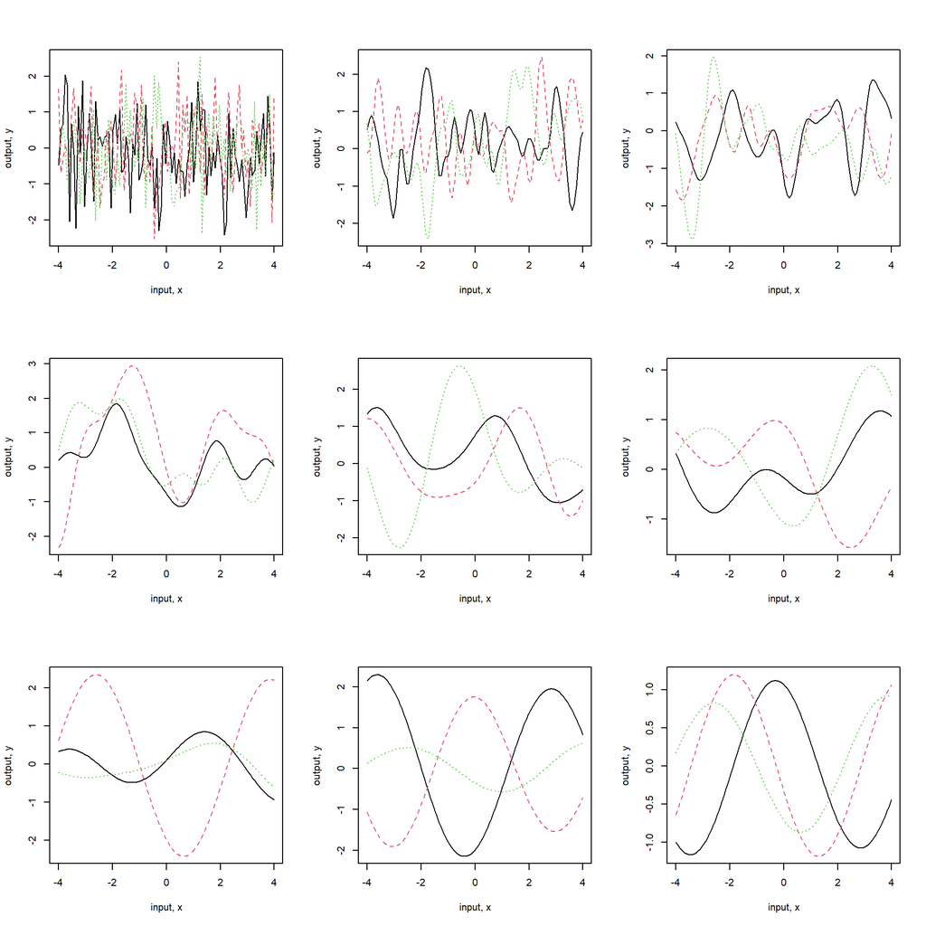

```r
kernel_pd <- function(xmin = -4,
                      xmax = 4,
                      length = 100,
                      scale = 1,
                      sigma = 1,
                      omega = 1) {
  x <- seq(xmin, xmax, length = length)
  d <- abs(outer(x, x, FUN = "-"))
  kernel <- sigma^2 * cos(omega * d) *
    exp(-0.5 * (d / 2)^2 / scale^2)
  kernel <- get_symm(kernel)
  kernel[is.na(kernel)] <- 0
  return(kernel)
}
op <- par(mfrow = c(3, 3))
x <- seq(-4, 4, length = 100)
l <- c(0.01, 0.1, 0.2,
        0.5, 1, 2,
        5, 10, 50)
for (i in 1:9) {
  sim <- mvtnorm::rmvnorm(3, sigma = kernel_pd(scale = l[i]))
  data <- cbind(x, t(sim)) %>%
    data.frame() %>%
    arrange(by = x)
  matplot(data[, 1], data[, -1],
    xlab = "input, x",
    ylab = "output, y",
    "l")
}
```

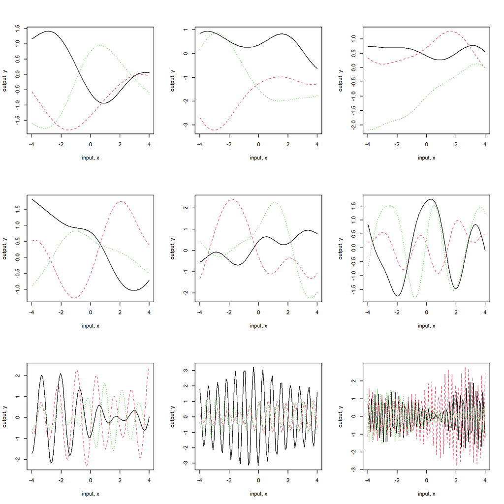

```r
par(op)

par(op)
op <- par(mfrow = c(3, 3))
w <- c(0.01, 0.1, 0.2,
       0.5, 1, 2,
       5, 10, 50)
for (i in 1:9) {
  sim <- mvtnorm::rmvnorm(3, sigma = kernel_pd(omega = w[i]))
  data <- cbind(x, t(sim)) %>%
    data.frame() %>%
    arrange(by = x)
  matplot(data[, 1], data[, -1],
    xlab = "input, x",
    ylab = "output, y",
    "l")
}
```

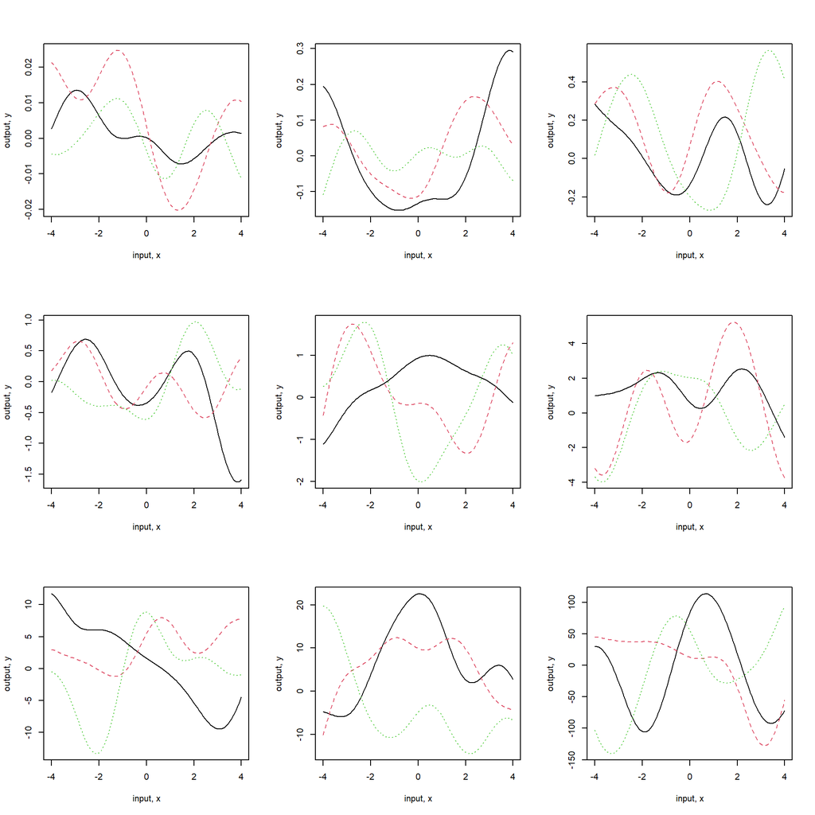

```r
par(op)
op <- par(mfrow = c(3, 3))
s <- c(0.01, 0.1, 0.2,
       0.5, 1, 2,
       5, 10, 50)
for (i in 1:9) {
  sim <- mvtnorm::rmvnorm(3, sigma = kernel_pd(sigma = s[i]))
  data <- cbind(x, t(sim)) %>%
    data.frame() %>%
    arrange(by = x)
  matplot(data[, 1], data[, -1],
    xlab = "input, x",
    ylab = "output, y",
    "l")
}
```

```r
par(op)
```

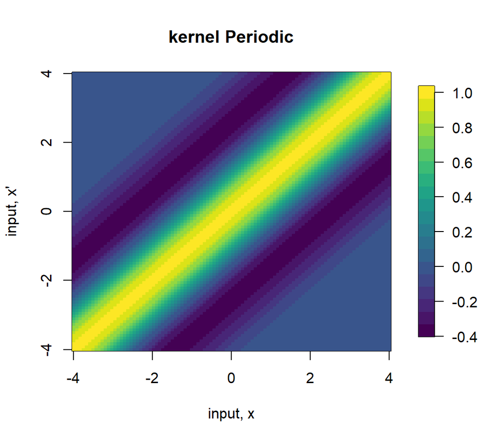

```r
x1 <- seq(-4, 4, length = 100)
kpd <- kernel_pd()
fields::image.plot(x1, x1, kpd,
                    xlab = "input, x",
                    ylab = "input, x'",
                    main = "kernel Periodic",
                    nlevel = 20,
                    col = viridis::viridis(20))
```

### 4.2.4 Making New Kernels from Old

$$\tilde k(x,\ x') = \frac {k(x,\ x')} {\sqrt {k(x,\ x)} \sqrt{k(x', x')}}
\ \ \ \ (4.35)$$

## 4.3 Eigenfunction Analysis of Kernels

an eigenfunction of kernel $k$ with eigenvalue $\lambda$ with respect to measure eigenfunction $\mu$. The two measures of particular interest to us will be: * (i) Lebesgue measure over a compact subset $\mathcal C$ of $\mathbb R^D$ * (ii) when there is a density $p(x)$ so that $dµ(x)$ can be written $p(x)dx$.

$$\int k(x,\ x')\phi(x) d\mu(x) = \lambda \phi(x')
\ \ \ \ (4.36)$$

**Theorem 4.2 (Mercer’s theorem)** Let $(X, \mu)$ be a finite measure space and $k \in L_\infty (\mathcal X^2,\ \mu^2)$ be a kernel such that $T_k: L_2(X,\ \mu) \rightarrow L_2(X,\ \mu)$ is positive definite *(see eq. (4.2))*. Let $\phi_i \in L_2(X,\ \mu)$ be the normalized eigenfunctions of T_k associated with the eigenvalues $\lambda_i > 0$. Then:

- 1. the eigenvalues $\{\lambda_i\}_\infty ^{i=1}$ are absolutely summable
- 2. $k(x,\ x') = \sum^{\infty}_{i=1} \lambda_i\phi_i(x)\phi^*_i (x')\ \ \ \ (4.37)$

holds $\mu^2$ almost everywhere, where the series converges absolutely and uniformly $\mu^2$ almost everywhere

**Definition 4.1** A degenerate kernel has only a finite number of non-zero eigenvalues

$$k(x - x') = \int_{\mathbb R^D}
e^{2\pi is \cdot (x-x')} d\mu(s) \\
= \int_{\mathbb R^D}
e^{2\pi is·x} \Big(e^{2\pi is \cdot x'}\Big)^* d\mu(s)
\ \ \ \ (4.38)$$

### 4.3.1 An Analytic Example

$$\lambda_k = \sqrt{\frac {2a} A} B^k \ \ \ \ (4.39)\\
\phi_k(x) = exp \big(- (c - a)x^2\big)H_k(\sqrt{2c}x)\ \ \ \ (4.40)$$

$$H_k(x) = (-1)^k exp(x^2) \int {d^k} {dx^k} exp(-x^2)
\ \ \ \ (4.41a)\\
a^{-1}=4\sigma^2\\
b^{-1}=2l^2\\
c=\sqrt{a^2 + 2ab}\\
A=a+b+c\\
B= b/A$$

### 4.3.2 Numerical Approximation of Eigenfunctions

$$\lambda_i\phi_i(x') = \int k(x, x')p(x)\phi_i(x) dx
\simeq \frac 1 n \sum^n_{l=1}
k(x_l, x')\phi_i(x_l)
\ \ \ \ (4.42)$$

$$Ku_i = \lambda^{mat}_i u_i
\ \ \ \ (4.43)$$

$$\phi_i(x') \simeq \frac {\sqrt {n}} {\lambda_i^{mat}} k(x')^{\top}u_i
\ \ \ \ (4.44)\\
k(x')^{\top} = \big(k(x1,\ x0),\ ... ,\ k(x_n,\ x')\big)$$

## 4.4 Kernels for Non-vectorial Inputs

### 4.4.1 String Kernels

$$k(x,\ x') = \sum_{s\in \mathcal A^∗}
w_s\phi_s(x)\phi_s(x')
\ \ \ \ (4.45)$$

### 4.4.2 Fisher Kernels

$$k(x,\ x') = \phi_\theta ^{(x)} M^{-1}\phi_{\theta}(x')
\ \ \ \ (4.46)$$

$$F = \mathbb E_x[\phi_\theta(x)\phi_{\theta}^{\top} (x)]
\ \ \ \ (4.47)$$

$$\nabla_\theta (log\ p(y = +1|x,\ \theta)-log\ p(y = -1|x,\ \theta))$$

## Summary

- constant: $\sigma_0^2$ *S*
- linear: $\sum^D_{d=1}\sigma^2_dx_dx_d'$
- polynomial: $(x \cdot x' + \sigma_0^2)^p$
- squared exponential: $exp\Big( \frac {r^2} {2l^2} \Big)$ *S*, *ND*
- Matern: $\frac 1 {2^{\nu-1}\Gamma (\nu)} \Big(\frac {\sqrt{2\nu}} {l} r\Big)^\nu K_\nu \Big(\frac {\sqrt{2\nu}} {l} r\Big)$ *S*, *ND*
- exponential: $exp\Big(- \frac r l\Big)$ *S*, *ND*
- $\gamma$-exponential: $exp \Big(-\big(\frac r l\big)^\gamma \Big)$ *S*, *ND*
- rational quadratic: $(1 + \frac {r^2} {2\alpha l^2})^{-\alpha}$ *S*, *ND*
- neural network: $\sin^{-1} \Big( {2\bar x^{\top}\sum\bar x'} {\sqrt{(1+2\bar x^{\top}\Sigma\bar x)(1+2\bar x'^{\top}\Sigma\bar x')}} \Big)$ *ND*

## 4.5 Exercises